# PHYS426 - Laminar Flow

Robert Payne & Julius Wang

# 1. Introduction

Flow can be characterized as laminar, turbulent, or transitional, depending on the relative importance of the inertial and viscous forces acting on the fluid. This can be quantified with a dimensionless ratio called the Reynold's number,

\begin{equation} \label{Re} Re = \frac{UL}{\nu} \end{equation}

where $U$ is the mean flow speed, $L$ is the hydraulic diameter of the pipe or channel, and $\nu$ is the kinematic viscosity of the fluid. If $\nu$ is large relative to $UL$, then $Re$ is small and viscous forces are dominant over inertial forces. If instead $UL$ is large compared to $\nu$, then $Re$ is large and inertial forces dominate over viscous forces.

Consider the flow in which viscous forces dominate over inertial forces. Such a flow is called laminar flow, wherein fluid particles tend to flow along smooth, continuous layers, with no cross-currents and mixing of mass or energy. Laminar flow can be easily visualized when dye is inserted into such a flow, as it will form a thin ribbon, tracing out and following a continuous streamline. Quantitatively, a flow is considered laminar when its Reynold's number is less than $2000$. Typical examples include flow over an aircraft wing and through through pipes.

Now consider the flow in which inertial forces are dominant. Such flows are turbulent, wherein fluid particles no longer flow in parallel layers, but instead whose motion is chaotic and often subject to rapid change in flow velocity and pressure. There is substantial exchange of energy and momentum between layers, and the formation of eddies of varying sizes. Dyes inserted into the flow will rapidly diffuse and spread throughout the fluid. Quantitatively, turbulent flow occurs for flows whose Reynold's number is greater than $4000$. Examples of turbulence include flow around a golf ball, smoke rising from a lit match, and general atmospheric circulation.

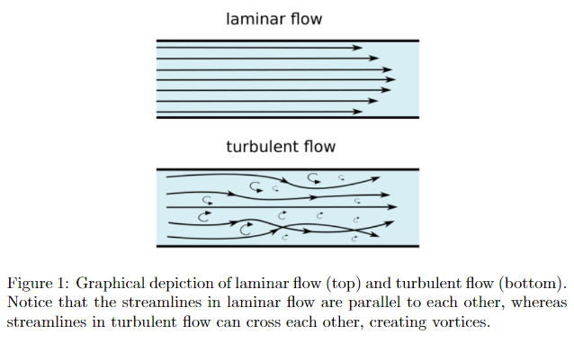

Finally, as its name suggests, transitional flow occurs in the transition from laminar flow to turbulent flow. Such flow occurs for Reynold's numbers in between $2000$ and $4000$. Qualitatively, such a flow would appear similar to laminar but with some mixing between layers and instability in the streamlines.

In this experiment, laminar and turbulent flow (and the transition between them) is investigated with two parts. The first parts uses an Osborne-Reynold's apparatus allowing for ample control of the flow regime. Measured parameters allow for the calculation of the flow's Reynold's number in order to determine consistency between theory and observation. The second part of this experiment concerns Taylor-Couette flow, wherein dye is inserted into a viscous fluid contained between two cylindrical walls. The inner wall is allowed to rotate, exerting a stress on the fluid and mixing the dye. When the wall is rotated in the opposite direction, the dye should ideally return to its original position, demonstrating that laminar flow is reversible.

# 2. Procedure

## Osborne-Reynolds Apparatus

The head tank of the Osborne Reynold’s apparatus (fig. 2) was filled with water until the hypodermic tube was submerged. The dye reservoir was filled with a solution of water and blue dye, and the dye flow control valve was released so that the dye solution began to drain into the head tank and bellmouth. The inflow control valve was carefully adjusted such that the flow through the test section was laminar. The flow rate out was measured by timing how long it took to fill a large beaker to a given volume. The temperature of the water was also noted, as the viscosity of water is temperature-dependent. This was repeated for transitional and turbulent flow.

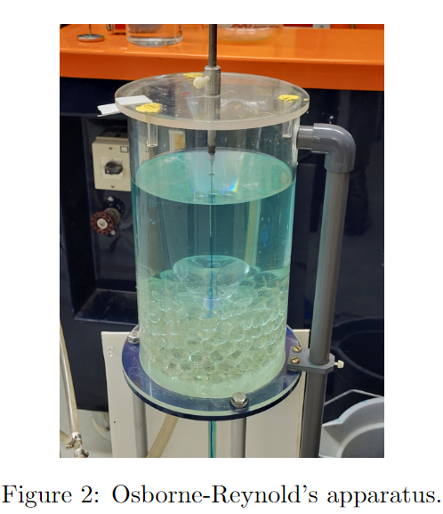

## Taylor-Couette Flow

A container consisting of an outer cylindrical wall and an inner cylindrical wall was filled with corn syrup (fig. 3). The outer wall was fixed in place while the inner wall could be rotated in order to exert a stress on the fluid. Using a pipette, several drops of dye (mixed with corn syrup as to create a neutrally- buoyant solution) were carefully inserted into the corn syrup. The inner cylinder was slowly rotated, exerting stress on the syrup and dye. After the dye had sufficiently spread and mixed, the inner wall was then slowly rotated back the opposite direction until the dye returned as close to its original location as possible.

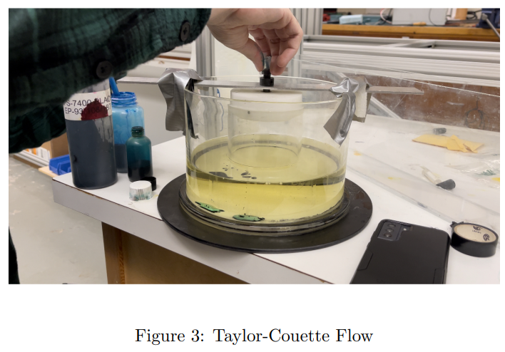

# 3. Results

## Osborne-Reynolds Apparatus

Three Reynold's numbers were calculated for each flow regime, based on the measured parameters below.

$\ $

T = Water temperature = 12.5°C

D = Pipe diameter = $0.015$m

$\nu$ = Kinematic viscosity = $1.218\times 10^{-6}$m$^2$/s

A = Cross-sectional area of the pipe = $1.77\times 10^{-4}$m$^2$

$\ $

$\ $

Laminar Flow : $Re<2000$

Transitional Flow: $2000<Re<4000$

Turbulent Flow: $Re>4000$

$\ $

Sample Calculations:

$u=\frac{\mathrm{volume}}{\mathrm{time}}$=$\frac{(0.6)(0.001\mathrm{m}^3)}{105\mathrm{s}}$=$5.714\times 10^{-6}\mathrm{m}^3/\mathrm{s}$

$U=\frac{u}{A}$=$\frac{5.714\times10^{-6}\mathrm{m}^3/\mathrm{s}}{1.77\times10^{-4}\mathrm{m}^2}$=$0.03228\mathrm{m}/\mathrm{s}$

$Re=\frac{UD}{\nu}$=$\frac{(0.03228\mathrm{m}/\mathrm{s})(0.015\mathrm{m})}{1.218\times10^{-6}\mathrm{m}^2/\mathrm{s}}=397.73$

Because $Re<2000$, the flow should be laminar.

$\ $ $\ $ $\ $ $\ $

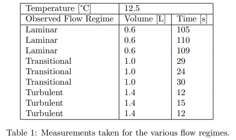

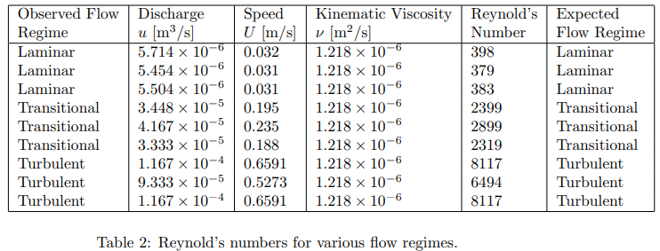

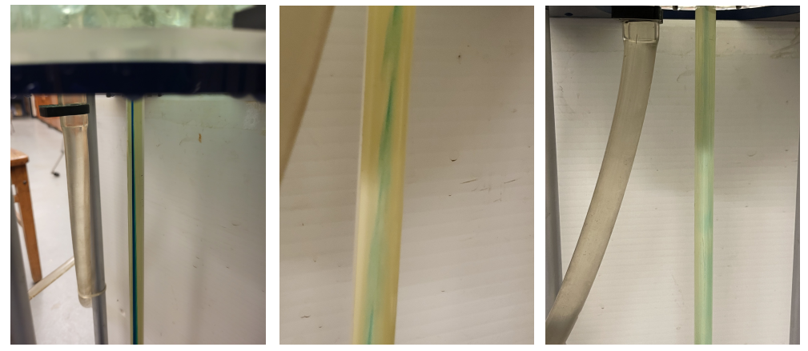

#### $\ $ $\ $ $\ $ $\ $ $\ $ $\ $ $\ $ $\ $ $\ $ $\ $ $\ $ $\ $ $\ $ $\ $ $\ $ $\ $ $\ $ $\ $ $\ $ $\ $ $\ $ $\ $ $\ $ $\ $ $\ $ $\ $ $\ $ Figure 4: From left to right: Laminar flow, transitional flow, turbulent flow.

## Taylor Couette Flow

We rotated the cylinder with slow speed, mixing the two dyes. Afterwards, the inner cylinder was reversed. As anticipated, the two dyes separated and returned to their original positions with minor differences, demonstrating that the flow was laminar.

# 4. Discussion

## Osborne-Reynolds Apparatus

The experiment producing various flow regimes with the Osborne-Reynolds (OR) apparatus was found to produce results consistent with theory. For laminar flow, Reynold's numbers of $398$, $379$, and $383$ were found, which are indeed less than the theoretical threshold of $Re<2000$. This flow was indeed observed to resemble "ribbons" of dye, closely following constant streamlines. For transitional flow, Reynold's numbers of $2399$, $2899$, $2319$ were found, again falling in between the theoretical threshold $2000<Re<4000$. This flow qualitatively resembled laminar flow with slightly more instability and curviness in the flow. Finally, Reynold's numbers of $8117$, $6494$, $8117$ were observed for turbulent flow, consistent with $Re>4000$. The flow in this regime quickly spread the dye out and did not follow constant streamlines, but instead mixed the dye quickly throughout the flow.

It's important to note that even the best laminar flow achieved exhibited small fluctuations uncharacteristic of its flow regime. Moreover, transitional flow was sometimes observed to suddenly transform into laminar flow or turbulent flow for periods of time. These indicate the presence of systematic errors with a substantial effect on the observed flow regime. Firstly, the water pump, while running, would cause the hydraulics table and OR apparatus to vibrate. To remedy this, the OR apparatus was placed firmly on the concrete floor. However, it could not be distanced very far from the Hydraulics table due to the lengths of tubes available, and hence the vibration may have affected the OR apparatus. This would serve to increase turbulence, as the shaking could breed instabilities that exponentially grow into turbulent flow. These kinds of instabilities may have also been induced through the handling of the apparatus, particularly through turning the flow control valve in order to achieve a certain regime. Air bubbles were also an issue throughout the course of the procedure. These typically occurred upon turning on the pump, and would take a few minutes to disappear. Future renditions of this experiment may wish to further distance the apparatus from the pump, and take special care in applying changes to the flow. After turning the pump on, the flow should be given several minutes to rid the system of air bubbles as much as possible.

## Taylor-Couette Flow

# 5. Hints & Suggestions

## Osborne-Reynolds Apparatus

- When turning the flow control valve in order to change the regime or achieve laminar flow, turn it very slowly, as the regime change can happen suddenly. Patience is key.
- Make sure the dye falls directly into the center of the bell mouth, as hitting the sides can create instability.
- Make sure the apparatus is on solid ground and remains unjostled.
- Take note of the water's temperature.
- Let the equipment run at least 5 minutes before taking data in order to rid the system of air bubbles.
- Watch the water level in the tank so it doesn't overflow, but also make sure the hypodermic tube is submerged.

## Taylor-Couette Flow

- In order to stop the dye from sinking to the bottom or floating to the top, create a solution of neutral buoyancy by mixing the dye with your viscous fluid of choice.
- Use a fluid with high viscosity. Corn syrup was found to work well.
- Turn the inner cylinder slowly. You can apply a bit of grease to reduce unwanted friction between the cylinder and the bottom. Avoid jostling.